# code

Group10

2024-03-03

# Inport dataset

```r
hr_data <- read.csv("./HR_Analytics.csv")
```

# 1. What numerical variables have the most impact on MonthlyIncome? Can we build a predictive model with reasonable performance to predict a employee’s monthly income(MonthlyIncome)?

By general understanding, there are some numerical variables that may also have impact on `MonthlyIncome`. 1. Age: Generally, with age comes more work experience, which can often lead to higher salaries. 2. DailyRate: Higher daily rates could suggest higher overall compensation packages. 3. DistanceFromHome: companies may offer higher salaries to attract talent who have a longer commute. 4. TotalWorkingYears: TotalWorkingYears reflects an employee’s experience level. 5. YearsAtCompany: Long-term employees may have received more incremental salary increases and promotions than newer employees. So we can do a correlation matrix to these variables

```r
cor(hr_data[c("MonthlyIncome", "Age", "DailyRate", "DistanceFromHome", "TotalWorkingYears", "YearsAtCompany")])
```

```
##                   MonthlyIncome           Age    DailyRate DistanceFromHome
## MonthlyIncome       1.000000000  0.4974859373  0.005963495    -0.0158170815
## Age                 0.497485937  1.0000000000  0.011583812    -0.0003290843
## DailyRate           0.005963495  0.0115838117  1.000000000    -0.0071343163
## DistanceFromHome   -0.015817082 -0.0003290843 -0.007134316     1.0000000000
## TotalWorkingYears   0.771806849  0.6808366086  0.015035807     0.0078023027
## YearsAtCompany      0.514469115  0.3105495586 -0.033737250     0.0101110343
##                   TotalWorkingYears YearsAtCompany
## MonthlyIncome           0.771806849     0.51446911
## Age                     0.680836609     0.31054956
## DailyRate               0.015035807    -0.03373725
## DistanceFromHome        0.007802303     0.01011103
## TotalWorkingYears       1.000000000     0.62756911
## YearsAtCompany          0.627569115     1.00000000
```

By the correlation matrix, we can see `TotalWorkingYears` has the most impact on MonthlyIncome.

Before we actually fit our model, We can use the scatter plot to check the linearity between them first.

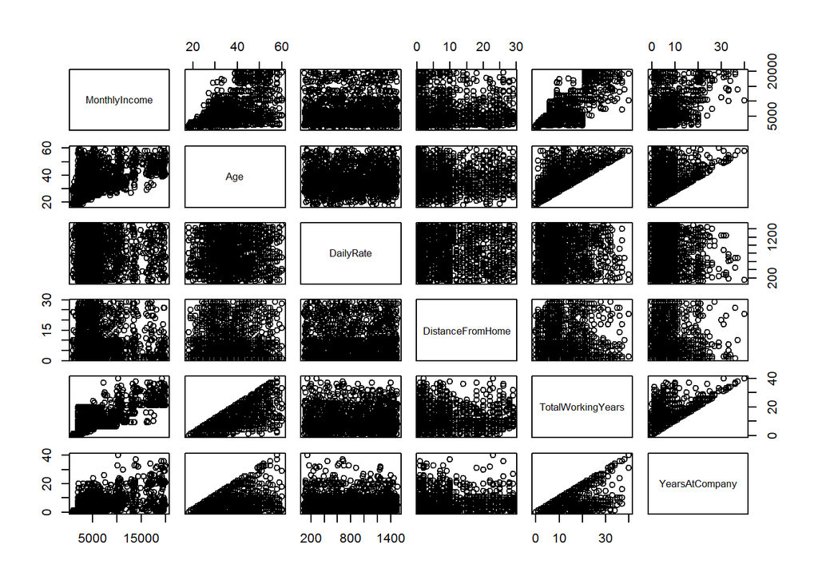

```r
pairs(~MonthlyIncome + Age + DailyRate + DistanceFromHome + TotalWorkingYears + YearsAtCompany, data = hr_data)
```

Since `age`, `TotalWorkingYears`, and `YearsAtCompany` has high linearity relationship, for the accurate of the coefficient, I decide to only keep `TotalWorkingYears` as our attribute.

By general understanding, there are some categorical variables that may also have impact on `MonthlyIncome`. 1. JobRole: Different job roles are associated with different pay scales. 2. Department: Pay scales can vary across departments depending on their function within the company. 3. EducationField: The field of study can influence starting salaries and income growth. 4. Education: The level of education attained can have a significant impact on earning potential. 5. Gender: There are known gender pay gaps in many industries and roles. 6. BusinessTravel: The amount of travel required for a job might impact salary. 7. OverTime: Employees who work overtime may have a higher MonthlyIncome due to overtime pay.

# 2. Is it appropriate to fit a linear model of monthly income(MonthlyIncome) in this data?